# Seq data analysis: Right side TO libs

E. coli ORBIT 2022

Scott H. Saunders

```r
library(tidyverse)
library(GenomicAlignments)
library(kableExtra)
library(ggridges)

knitr::opts_chunk$set(tidy.opts=list(width.cutoff=60),tidy=FALSE, echo = TRUE, message=FALSE, warning=FALSE, fig.align="center", fig.retina = 2)

source("../tools/plotting_tools.R")
theme_set(theme_notebook())
```

Within each library the targeting oligo deletes a target gene, and pInt_kanR should integrate into the newly formed attB site on the genome. This should leave us with a library with the target genes deleted, replaced by the pInt_kanR backbone flanked by the attR and attL sites. To test the accuracy with which these libraries were constructed sequencing libraries were prepared to amplify these genome-pInt junctions. This was done by shearing genomic DNA, adding C tails to free DNA ends and then amplifying junctions with a polyG and pInt specific primer. This notebook takes the processed (filtered, trimmed, mapped) reads from the processing notebook and uses these mapped sequences to analyze how accurately the designed ORBIT mutants were created.

# Read in data and figure out TO / read orientation

First, we need to read in the mapped reads for each right side library. These are stored as bam files. Here we combine all of the mapped reads into one dataframe that will go through analysis.

```r
bam_path <- "../../data/seq_data/right_side_TO_libs/6_bam_files/"

df_bam_0_1 <- readGAlignments(file = paste0(bam_path,"lib_0_right_mapped.bam")) %>% as_tibble() %>% mutate(lib=0)

df_bam_1_1 <- readGAlignments(file = paste0(bam_path,"lib_1_right_mapped.bam")) %>% as_tibble() %>% mutate(lib=1)

df_bam_2_1 <- readGAlignments(file = paste0(bam_path,"lib_2_right_mapped.bam")) %>% as_tibble() %>% mutate(lib=2)

df_bam_3_1 <- readGAlignments(file = paste0(bam_path,"lib_3_right_mapped.bam")) %>% as_tibble() %>% mutate(lib=3)

#df_bam_0 %>% group_by(start) %>% summarise(n=n()) %>% arrange(desc(n))


df_data_all <- bind_rows(df_bam_0_1,df_bam_1_1,df_bam_2_1,df_bam_3_1)

df_data_all %>% head(10) %>% kable() %>% kable_styling()
```

seqnames

strand

cigar

qwidth

start

end

width

njunc

lib

U00096.3

79M2S

81

2978946

2979024

79

0

0

U00096.3

6S47M

53

2095079

2095125

47

0

0

U00096.3

81M

81

4277913

4277993

81

0

0

U00096.3

76M

76

3535810

3535885

76

0

0

U00096.3

2S78M

80

317133

317210

78

0

0

U00096.3

51M

51

3059708

3059758

51

0

0

U00096.3

2S30M

32

2095096

2095125

30

0

0

U00096.3

81M

81

3535805

3535885

81

0

0

U00096.3

75M

75

4099474

4099548

75

0

0

U00096.3

34M2S

36

417811

417844

34

0

0

This full data frame is ~330k lines, meaning that we are working with that many reads total. Next we need to read in the information for the targeting oligos that we designed. Each oligo was ordered to delete a certain region of the genome, as specified by a left and right genomic position, corresponding roughly to the start and end of the target genes. Here we read in the information for the different TO libraries.

```r
df_TOs <- read_csv("../../../ecoli_ORBIT_paper_final/data/seq_data/right_side_TO_libs/df_TOs.csv")

df_TOs
```

```
## # A tibble: 420 × 7
##      lib gene  left_oligo_pos right_oligo_pos oligo              product go_term
##    <dbl> <chr>          <dbl>           <dbl> <chr>              <chr>   <chr>
##  1     1 alpA         2758649         2758836 CTCTCTGCAACCAAAGT… CP4-57… DNA bi…
##  2     1 argR         3384708         3385153 GCACAATAATGTTGTAT… DNA-bi… DNA bi…
##  3     1 ariR         1216374         1216615 AAACTTATACTTAATAA… putati… protei…
##  4     1 arsR         3648533         3648861 TCGAAGAGAGACACTAC… DNA-bi… transc…
##  5     1 asnC         3926565         3926998 TAAAATAGAATGAATCA… DNA-bi… protei…
##  6     1 bolA          454477          454769 GCGCCGACAGTTGCAAA… DNA-bi… protei…
##  7     1 caiF           34305           34675 ACGCCCGGTATCAACGA… DNA-bi… DNA-bi…
##  8     1 cedA         1813441         1813658 GCAAAACCGGGAGGTAT… cell d… DNA bi…
##  9     1 cspA         3720054         3720241 TCGCCGAAAGGCACACT… cold s… nuclei…
## 10     1 cspC         1907246         1907430 CACACTTCAGATCAGTG… stress… nuclei…
## # … with 410 more rows
```

Figure out starting position of read for each TO. Remember that only the fwd sequence of attB was used in the actual oligo to prevent PCR issues. Normally the attB sequence would be directed the same way as the gene, but here the only thing that affects the directionality is the replichore. So for replichore 1 (>3.9M & <1.6M), the oligo sequence comes from the reverse strand, meaning that the attB also points “reverse”. Therefore when sequencing the “right side library” the read maps to the forward + strand and the “left side library” maps to the reverse - strand. For replichore 2 it is the opposite. The TO sequence comes from the + strand, meaning attB points fwd. Therefore the upstream (aka right) library maps to the - strand and the downstream (aka left) maps to the + strand.

We can see the evidence that this is actually how the ORBIT library sequences are oriented by looking at which strand the reads map to vs. the genomic position (replichore).

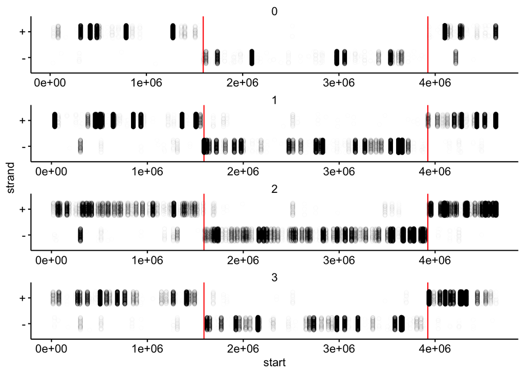

```r
ggplot(df_data_all %>% mutate(strand = factor(strand, levels = c('-','+'))) ,
       aes(x = start, y = strand)) +
  geom_vline(xintercept = c(1590250.5,3923882.5), color = 'red')+
  geom_jitter(height=0.25, shape =21, alpha = 0.01)+
  facet_wrap(~lib, ncol = 1, scales = 'free')
```

It is clear that most reads are coming from the + strand on replichore 1 for all libraries, and the - strand for replichore 2 as expected. Interestingly, the small number of reads that do not conform to this, may indicate an off target integration that wasn’t specified in our designed TO library.

This orientation issue is important to understand, because we need to be able to match the mapped reads to where we expect a read to start if the designed TO worked perfectly. Now that we know our orientation intuition seems right, we can look at the list of TOs and assign what should be the theoretical “read_start_position” if the mutant were made perfectly. Remember these oligos were specified by the region between two genomic positions (left_oligo_pos & right_oligo_pos), so the first genomic sequence outside of these insertions should either be the left or right specified position. The upstream junction (aka right) should start at the right_oligo_pos for replichore 1 targets, and the left_oligo_pos for replichore 2 targets based on their orientations.

Therefore, we will just assign the correct oligo pos to the TOs.

```r
ori <-  3923882.5
ter <-  1590250.5

##*** CHANGING FOR RIGHT SIDE

df_TOs <- df_TOs %>%
  mutate(gen_rep = ifelse(left_oligo_pos < ori & left_oligo_pos > ter, 2,1)) %>%
  mutate(read_start_pos = ifelse(gen_rep==1, right_oligo_pos,left_oligo_pos)) %>%
  mutate(read_start_pos = ifelse(gene == 'metA', left_oligo_pos, read_start_pos)) #metA is the only special case, because it uses the - direction attB site in lib 0.

df_TOs
```

```
## # A tibble: 420 × 9
##      lib gene  left_oligo_pos right_olig…¹ oligo product go_term gen_rep read_…²
##    <dbl> <chr>          <dbl>        <dbl> <chr> <chr>   <chr>     <dbl>   <dbl>
##  1     1 alpA         2758649      2758836 CTCT… CP4-57… DNA bi…       2 2758649
##  2     1 argR         3384708      3385153 GCAC… DNA-bi… DNA bi…       2 3384708
##  3     1 ariR         1216374      1216615 AAAC… putati… protei…       1 1216615
##  4     1 arsR         3648533      3648861 TCGA… DNA-bi… transc…       2 3648533
##  5     1 asnC         3926565      3926998 TAAA… DNA-bi… protei…       1 3926998
##  6     1 bolA          454477       454769 GCGC… DNA-bi… protei…       1  454769
##  7     1 caiF           34305        34675 ACGC… DNA-bi… DNA-bi…       1   34675
##  8     1 cedA         1813441      1813658 GCAA… cell d… DNA bi…       2 1813441
##  9     1 cspA         3720054      3720241 TCGC… cold s… nuclei…       2 3720054
## 10     1 cspC         1907246      1907430 CACA… stress… nuclei…       2 1907246
## # … with 410 more rows, and abbreviated variable names ¹right_oligo_pos,
## #   ²read_start_pos
```

There is one exception here, which is the *metA* oligo. This is because this oligo was only in the library 0 from IDT, which did not require PCR amplification, so the same oligo sequence was used as from the rest of the paper, which has attB facing the opposite orientation as the scheme described above (attB faces the same way as the gene).

# Match reads to putative TOs

With all that sorted we can now iterate through every read in the dataset and try to find the closest TO match. Then we can evaluate how close the reads are to the expected start sites for their inferred TO.

This for loop achieves this very simply, by iterating through each read, then measuring the distance between the read start position and the start positions of every TO designed for that library. The nearest TO is assigned to the read as a ‘gene_id’ and that minimum distance is recorded with the read. This loop takes ~30 min to run on a desktop, but the csv output can be read in without running.

```r
# Takes ~30 min to run

#Initialize dataframe to store reads
df_read_nearest <- tibble()

#Based on alignment, if read maps to + strand, then the illumina start of the read is the start of the alignment.
#if read maps to - strand then illumina read start is actually the end of the mapped read
df_test <- df_data_all %>%
  mutate(read_start_pos = ifelse(strand =='+', start, end))

#Pre split the different TOs into dataframes by library to make loop run faster.
df_TO_0 <- df_TOs %>% filter(lib==0)
df_TO_1 <- df_TOs %>% filter(lib==1)
df_TO_2 <- df_TOs %>% filter(lib==2)
df_TO_3 <- df_TOs %>% filter(lib==3)

#Iterates through each mapped read
for( row in 1:nrow(df_test)){

  #picks the set of TOs that matches the library number
  if(df_test$lib[row]==0){
    df_to <- df_TO_0
    }else if(df_test$lib[row]==1){
    df_to <- df_TO_1
    }else if(df_test$lib[row]==2){
    df_to <- df_TO_2
    }else if(df_test$lib[row]==3){
    df_to <- df_TO_3
    }

  #Compares the `read start pos` of each designed TO in the library, to the `read start pos` of the read (vector).
  #Then finds the minimum difference min(abs()) of the distances between this read and all TOs
  min_val <- min(abs(df_to$read_start_pos - df_test$read_start_pos[row]))

  #Same as above, but returns the TO index of the min val,
  #which is then used to get the actual TO that has the closest start pos to the read.
  #The gene this TO deletes is assigned to the read as `gene_id` and the min_val is also stored
  min_index <- which.min(abs(df_to$read_start_pos - df_test$read_start_pos[row]))
  gene_id <- df_to$gene[min_index]
  df_reads <- tibble(df_test[row,],gene_id = gene_id, min_val = min_val)

  #add this read to the growing dataframe of processed reads
  df_read_nearest <- bind_rows(df_read_nearest, df_reads)

}

df_read_nearest

write_csv(df_read_nearest, '../../data/seq_data/right_side_TO_libs/df_read_nearest_right.csv')
```

Now that we have gone through and categorized each read and calculated the minimum distance to a TO target, we can further classify reads as perfect (`min_val=0`) or as off target if it falls beyond 500bp away (`min_val>500`). Then we can get summary statistics. What fraction of reads are off target?

```r
df_read_nearest <- read_csv('../../data/seq_data/right_side_TO_libs/df_read_nearest_right.csv')

df_read_nearest <- df_read_nearest %>%
  mutate(gene_id = ifelse(min_val >500, 'off_target',gene_id)) %>%
  mutate(off_target = ifelse(gene_id=='off_target',T,F)) %>%
  mutate(perfect = ifelse(min_val==0, T, F))

df_read_nearest %>% group_by(lib, off_target) %>% summarise(n=n()) %>%
  pivot_wider(names_from = off_target, names_prefix = 'off_target_', values_from = n) %>%
  mutate(total =off_target_TRUE + off_target_FALSE) %>%
  mutate(frac_off_target = off_target_TRUE / (off_target_TRUE + off_target_FALSE))
```

```
## # A tibble: 4 × 5
## # Groups:   lib [4]
##     lib off_target_FALSE off_target_TRUE  total frac_off_target
##   <dbl>            <int>           <int>  <int>           <dbl>
## 1     0            36557            1440  37997          0.0379
## 2     1           119828            1473 121301          0.0121
## 3     2            93744            3159  96903          0.0326
## 4     3            73839            1813  75652          0.0240
```

Less than 4% of reads are off target across all the libraries! And we can also look at how many reads were perfect:

```r
df_read_nearest %>% group_by(lib, perfect) %>% summarise(n=n()) %>%
  pivot_wider(names_from = perfect, names_prefix = 'perfect_', values_from = n) %>%
  mutate(total = perfect_TRUE + perfect_FALSE) %>%
  mutate(frac_perfect = perfect_TRUE / (perfect_TRUE + perfect_FALSE))
```

```
## # A tibble: 4 × 5
## # Groups:   lib [4]
##     lib perfect_FALSE perfect_TRUE  total frac_perfect
##   <dbl>         <int>        <int>  <int>        <dbl>
## 1     0          1779        36218  37997        0.953
## 2     1          2362       118939 121301        0.981
## 3     2          3835        93068  96903        0.960
## 4     3          2832        72820  75652        0.963
```

More than 95% of reads from all the libraries were perfect! We can visualize the perfect and off target score graphically, which is shown as a summary metric in the main fig:

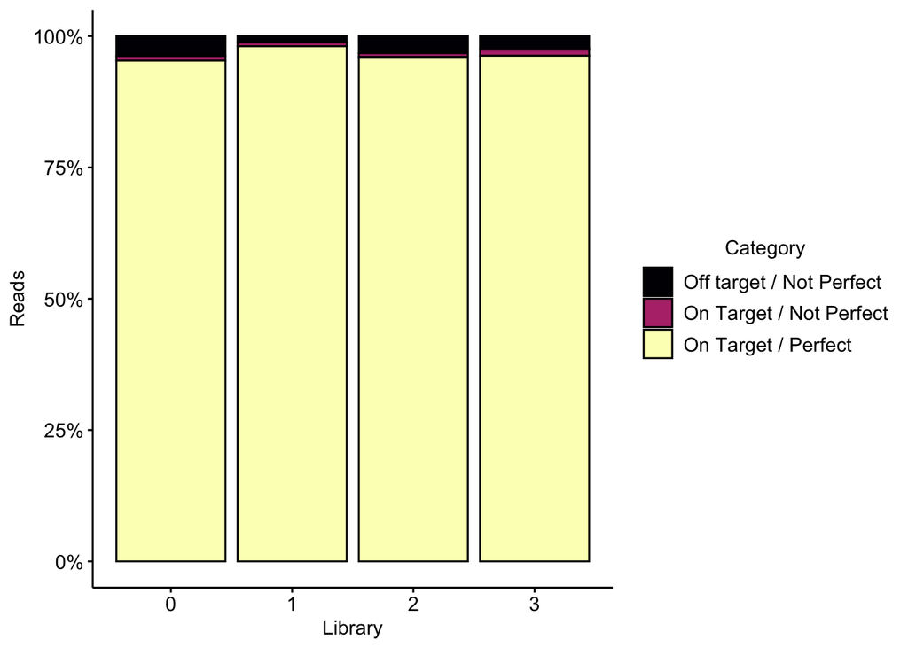

```r
df_read_nearest %>%
  mutate(status = paste0('off_',off_target, '_p_',perfect)) %>%
  mutate(status = fct_relevel(status, 'off_TRUE_p_FALSE','off_FALSE_p_FALSE','off_FALSE_p_TRUE')) %>%
  ggplot(aes(x = lib, fill = status)) +
    geom_bar(color = 'black',position = 'fill') +
    scale_y_continuous(labels = scales::label_percent())+
    scale_fill_viridis_d(labels = c('Off target / Not Perfect','On Target / Not Perfect','On Target / Perfect'), option = 'A')  +
    labs(y = 'Reads', x = 'Library', fill = 'Category')
```

# How many of the intended TO mutations were recovered?

Instead of taking a “read-centric” view, we can instead take a “target-centric” view and ask how many of the TOs we designed actually yielded mutants in our libraries. First we will count up all the reads for each gene_id - this will also be useful later.

```r
#Group by lib and gene and count up reads assigned to each gene
df_read_nearest_summary <- df_read_nearest %>%
  group_by(lib, gene_id) %>%
  summarise( n=n(), min_val = mean(min_val))

df_read_nearest_summary %>% head(10) %>% kable() %>% kable_styling()
```

| lib | gene_id | n | min_val |
| --- | --- | --- | --- |
| 0 | acrR | 2048 | 0.0668945 |
| 0 | alaS | 2 | 0.0000000 |
| 0 | argP | 1419 | 0.0105708 |
| 0 | arsR | 411 | 13.7639903 |
| 0 | envR | 242 | 0.0082645 |
| 0 | fnr | 114 | 0.0000000 |
| 0 | fur | 15 | 0.0000000 |
| 0 | galK | 3268 | 0.0113219 |
| 0 | galR | 1361 | 0.2659809 |
| 0 | hisA | 3046 | 0.0045962 |

And then we will see if there are any TOs that have no reads. From there we can look at the fraction of each TO library for which a mutant was not recovered (within the 500bp threshold).

```r
#Merge the read counts
df_TOs_found <- left_join(df_TOs, df_read_nearest_summary, by = c('gene'='gene_id', 'lib')) %>%
  mutate(found = ifelse(is.na(n) & is.na(min_val), F, T))

df_TOs_found %>%
  group_by(lib, found) %>%
  summarise(n=n()) %>%
  pivot_wider(names_from = found, names_prefix = 'found_', values_from = n, values_fill = 0) %>%
  mutate(frac_found = found_TRUE / (found_TRUE + found_FALSE))
```

```
## # A tibble: 4 × 4
## # Groups:   lib [4]
##     lib found_TRUE found_FALSE frac_found
##   <dbl>      <int>       <int>      <dbl>
## 1     0         27           0      1
## 2     1         69           5      0.932
## 3     2        208          18      0.920
## 4     3         84           9      0.903
```

So for all 4 libraries, at least 90% of the TOs were found with mutants represented. These are the mutants that were not found:

```r
df_TO_not_found <- df_TOs_found %>% filter(found == F)

df_TO_not_found %>% select(-go_term,-oligo) %>% kable() %>% kable_styling()
```

| lib | gene | left_oligo_pos | right_oligo_pos | product | gen_rep | read_start_pos | n | min_val | found |
| --- | --- | --- | --- | --- | --- | --- | --- | --- | --- |
| 1 | dicA | 1647939 | 1648321 | DNA-binding transcriptional dual regulator DicA | 2 | 1647939 | NA | NA | FALSE |
| 1 | hns | 1292529 | 1292917 | DNA-binding transcriptional dual regulator H-NS | 1 | 1292917 | NA | NA | FALSE |
| 1 | iscR | 2661663 | 2662126 | DNA-binding transcriptional dual regulator IscR | 2 | 2661663 | NA | NA | FALSE |
| 1 | mqsA | 3167871 | 3168241 | antitoxin of the MqsRA toxin-antitoxin system / DNA-binding transcriptional repressor MqsA | 2 | 3167871 | NA | NA | FALSE |
| 1 | racR | 1419785 | 1420236 | Rac prophage; DNA-binding transcriptional repressor RacR | 1 | 1420236 | NA | NA | FALSE |
| 2 | alaS | 2819401 | 2822006 | alanine&mdash;tRNA ligase/DNA-binding transcriptional repressor | 2 | 2819401 | NA | NA | FALSE |
| 2 | arcA | 4639610 | 4640301 | ArcA-P<sup>asp54</sup>-phosphate // Phosphorylated DNA-binding transcriptional dual regulator ArcA // DNA-binding transcriptional dual regulator ArcA | 1 | 4640301 | NA | NA | FALSE |
| 2 | birA | 4173087 | 4174027 | DNA-binding transcriptional repressor/biotin-[acetyl-CoA-carboxylase] ligase BirA | 1 | 4174027 | NA | NA | FALSE |
| 2 | dcuR | 4349335 | 4350029 | DcuR // DNA-binding transcriptional activator DcuR | 1 | 4350029 | NA | NA | FALSE |
| 2 | dnaA | 3882346 | 3883724 | chromosomal replication initiator protein DnaA | 2 | 3882346 | NA | NA | FALSE |
| 2 | fnr | 1398794 | 1399521 | DNA-binding transcriptional dual regulator FNR | 1 | 1399521 | NA | NA | FALSE |
| 2 | gadX | 3665006 | 3665805 | DNA-binding transcriptional dual regulator GadX | 2 | 3665006 | NA | NA | FALSE |
| 2 | gntR | 3577751 | 3578721 | DNA-binding transcriptional repressor GntR | 2 | 3577751 | NA | NA | FALSE |
| 2 | lexA | 4257120 | 4257703 | DNA-binding transcriptional repressor LexA | 1 | 4257703 | NA | NA | FALSE |
| 2 | metR | 4011883 | 4012811 | DNA-binding transcriptional dual regulator MetR | 1 | 4012811 | NA | NA | FALSE |
| 2 | nusA | 3316059 | 3317521 | transcription termination/antitermination protein NusA | 2 | 3316059 | NA | NA | FALSE |
| 2 | obgE | 3330602 | 3331749 | GTPase ObgE | 2 | 3330602 | NA | NA | FALSE |
| 2 | rpoD | 3213052 | 3214868 | RNA polymerase, sigma 70 (sigma D) factor | 2 | 3213052 | NA | NA | FALSE |
| 2 | rpoE | 2709457 | 2710007 | RNA polymerase sigma E factor | 2 | 2709457 | NA | NA | FALSE |
| 2 | rpoH | 3599949 | 3600778 | RNA polymerase, sigma 32 (sigma H) factor | 2 | 3599949 | NA | NA | FALSE |
| 2 | uvrY | 1994723 | 1995354 | Phosphorylated DNA-binding transcriptional activator UvrY // DNA-binding transcriptional activator UvrY | 2 | 1994723 | NA | NA | FALSE |
| 2 | yheO | 3475738 | 3476435 | DNA-binding transcriptional regulator YheO | 2 | 3475738 | NA | NA | FALSE |
| 2 | yidP | 3863904 | 3864595 | putative DNA-binding transcriptional regulator YidP | 2 | 3863904 | NA | NA | FALSE |
| 3 | 3’ETS-<i>leuZ</i> | 1991747 | 1991815 | small regulatory RNA 3’ETS<sup><i>leuZ</i></sup> | 2 | 1991747 | NA | NA | FALSE |
| 3 | esrE | 4019977 | 4020230 | small RNA EsrE | 1 | 4020230 | NA | NA | FALSE |
| 3 | ffs | 476447 | 476562 | signal recognition particle 4.5S RNA | 1 | 476562 | NA | NA | FALSE |
| 3 | gadY | 3664863 | 3664970 | small regulatory RNA GadY | 2 | 3664863 | NA | NA | FALSE |
| 3 | gcvB | 2942695 | 2942902 | small regulatory RNA GcvB | 2 | 2942695 | NA | NA | FALSE |
| 3 | ohsC | 2700519 | 2700599 | small regulatory RNA OhsC | 2 | 2700519 | NA | NA | FALSE |
| 3 | orzP | 2204401 | 2204485 | small RNA OrzP | 2 | 2204401 | NA | NA | FALSE |
| 3 | sroE | 2640594 | 2640687 | small RNA SroE | 2 | 2640594 | NA | NA | FALSE |
| 3 | tff | 189711 | 189848 | putative small RNA T44 | 1 | 189848 | NA | NA | FALSE |

There are 32 spread across the 3 twist libraries. We will investigate in further detail in combination with the left side library.